# HW 2-PART 2

Lorenzo Di Giannantonio,Simone Cuonzo and Elisa Battista

2025-01-11

$$PART 2$$

###Point a and b :Online Expert Aggregation on ACI (AgACI)

The **AgACI** method involves running the same **ACI algorithm** multiple times, each with different values of $\gamma$ (denoted $\gamma_k$ for $k \in \{1, \dots, K\}$), which generates $K$ distinct values of $\alpha_t^{(k)}$ at each time $t$. These values are then combined to form the final prediction interval.

Each value of $\gamma_k$ corresponds to an “expert,” and the goal is to aggregate the prediction bounds from each expert into a final set of bounds. This is done by calculating a **weighted mean** of the $K$ intervals, with weights determined by each expert’s historical performance. Specifically, the weights are derived using the **pinball loss function** ($\rho_\beta$), which quantifies how well each expert’s prediction matches the true outcome.

Inputs required:

- the miscoverage rate $\alpha$
- a grid of values for $\gamma$ ${\gamma_k, k \in[1,K]}$
- the aggregation rule $\Phi$ (we can choose among different ones in R) and it can include the computation of the gradients of the loss (gradient trick)
- threshold values $M$ for the lower and the upper bounds (since aggregation rules require bounded experts)

At each temporal step the algorithm performs two independent aggregations of the K-ACI intervals
$$\hat{C}_{\alpha_t,t}(.)=[\hat{b}_{t,k}^{(l)}(.),\hat{b}_{t,k}^{(u)}(.)]$$
and outputs
$$\tilde{C}_t(.)=[\tilde{b}_{t}^{(l)}(.),\tilde{b}_{t}^{(u)}(.)]$$
Weights are computed as:

$$\omega_{t,k}^{(.)} = \Phi \big( \rho_{\beta^{(.)}}(y_s,
\hat{b}_{s,l}^{(.)}(x_s)), \; s \in [T_0+1, t], \; l \in [1, k] \big)$$

where $\beta^{(l)}$ is set to $\frac{\alpha}{2}$ and $\beta^{(u)}$ is set to $1-\frac{\alpha}{2}$

As aggregation rule, the autors have chosen The Bernstein Online Aggregation (BOA) procedure. The weights outputted by BOA have an exponential form. In the exponent is plugged the difference between the loss suffered by the last aggregated forecast and the current squared loss suffered by the expert.

In order to adapt this strategy to build the prediction intervals of our eGARCH(1,1)-std model, what we present below is a version inspired by, but slightly different from, that of the AgACI just described. The inputs are the same ones we use in the original Agaci. Instead of building the lower and upper bounds of the prediction interval for each expert and then building the “aggregate” bounds, we focus directly on the $\alpha_t$. Each expert produces an $\alpha_{t}^{(k)}$ and what we want to do is create an “aggregate” $\widetilde{\alpha}_{t}$ given by the weighted average of the $\alpha_{t}^{(k)}$. The weights of each expert are calculated with a BOA aggregation and with an MSE loss function. The arguments of the MSE are a constant vector with elements equal to the miscoverage rate $\alpha$ and the cumulative average of the errors of each expert $k$:

$$\widehat{e}_t^{(k)}
=
\frac{1}{t} \sum_{s=1}^{t} \text{err}_s^{(k)}.$$

In this way we give more weight to the experts who guarantee us a better coverage rate (i.e. close to $\alpha$) over time.

The aggregate estimate looks like this:

$$\widetilde{\alpha}_{t+1}
=
\sum_{g=1}^K w_t^{(g)} \;\alpha_{t+1}^{(g)}.$$

once we have $\widetilde{\alpha}_t$, we calculate the error of the aggregate $\text{err}_t^{(\text{agg})}$ which will then be compared with the errors of the experts $\text{err}_t^{(k)}$.

```r
library(quantmod)
library(rugarch)
library(opera)
library(dplyr)
```

```r
agaciVolatilityForecasting <- function(returns, alpha = 0.05,
                                       gammaGrid = seq(0.001, 0.01, by = 0.001),
                                       lookback = 1250, garchP = 1, garchQ = 1,
                                       startUp = 100, verbose = FALSE,
                                       updateMethod = "Momentum", momentumBW = 0.95) {
  myT <- length(returns)
  T0 <- max(startUp, lookback)

  garchSpec <- ugarchspec(
    mean.model = list(armaOrder = c(0, 0), include.mean = FALSE),
    variance.model = list(model = "eGARCH", garchOrder = c(garchP, garchQ)),
    distribution.model = "std"  # Heavy-tailed distribution
  )

  # Initialize storage variables
  K <- length(gammaGrid)  # Number of "experts"
  Tlen <- myT - T0

  # Vector to store GARCH (variance) predictions at each step
  garchForecastVec <- rep(NA, Tlen)

  scores          <- array(NA, dim = Tlen)
  alphaSeq        <- matrix(alpha, nrow = K, ncol = Tlen)

  alphaSeq2       <- rep(alpha, Tlen)  # Base alpha for the BOA part

  errSeqOC        <- matrix(NA, nrow = K, ncol = Tlen)  # Matrix for errors of each expert
  aggregatedalpha <- rep(NA, Tlen)
  err             <- rep(NA, Tlen)  # Vector for aggregated errors

  lower_limit <- 0.001
  upper_limit <- 0.999

  # 1) Interval lengths for experts (Tlen x K)
  intervalLengths <- matrix(NA, nrow = Tlen, ncol = K)

  # 2) Interval lengths for the aggregate (Tlen)
  intervalLengths2 <- rep(NA, Tlen)

  # === 1) Compute predictions using the ACI logic ===
  for (t in T0:(myT - 1)) {

    # Fit GARCH and forecast
    garchFit     <- ugarchfit(garchSpec, returns[(t - lookback + 1):(t - 1)], solver = "hybrid")
    sigmaNext    <- sigma(ugarchforecast(garchFit, n.ahead = 1))
    garchForecast <- sigmaNext^2  # GARCH forecast

    colIdx <- t - T0 + 1

    # Save GARCH forecast
    garchForecastVec[colIdx] <- garchForecast

    # Conformity score
    scores[colIdx] <- abs(returns[t]^2 - sigmaNext^2) / sigmaNext^2

    # Historical scores
    historical <- scores[max(1, colIdx - lookback + 1):(colIdx - 1)]

    # Compute thresholds and update alpha for each expert
    for (g in seq_along(gammaGrid)) {
      gamma <- gammaGrid[g]

      if (t == T0) {
        thr <- quantile(historical, 1 - alpha)
        errSeqOC[g, colIdx] <- as.numeric(scores[colIdx] > thr)
        intervalLengths[colIdx, g] <- 2 * thr

      } else {
        thr <- quantile(historical, 1 - alphaSeq[g, colIdx - 1])
        errSeqOC[g, colIdx] <- as.numeric(scores[colIdx] > thr)
        intervalLengths[colIdx, g] <- 2 * thr

        # Update alphaSeq
        if (updateMethod == "Simple") {
          alphaSeq[g, colIdx] <- alphaSeq[g, colIdx - 1] + gamma * (alpha - errSeqOC[g, colIdx])

        } else if (updateMethod == "Momentum") {
          w <- rev(momentumBW^(1:(colIdx - 1)))
          w <- w / sum(w)
          alphaSeq[g, colIdx] <- alphaSeq[g, colIdx - 1] + gamma * (alpha - sum(errSeqOC[g, colIdx] * w))
        }

        # Clipping
        alphaSeq[g, colIdx] <- min(upper_limit, max(lower_limit, alphaSeq[g, colIdx]))
      }
    }
  }

  # Cumulative mean for each column
  cummean_cols <- apply(errSeqOC, 2, cummean)


  # === 2) Aggregation using BOA ===
  aggalpha <- mixture(
    Y       = alphaSeq2,
    experts = t(cummean_cols),
    model   = "BOA",
    loss.gradient = TRUE,
    loss.type = 'square'
  )

  print(aggalpha$weights)

  # Convert weights to a data frame for readable output
  weights_df <- as.data.frame(aggalpha$weights)
  colnames(weights_df) <- paste0("Expert_", 1:K)  # Names for experts
  rownames(weights_df) <- paste0("T", 1:nrow(weights_df))  # Names for time steps

  # Print the first 10 rows as an example
  print(head(weights_df, 10))

  # Compute aggregate and error vector for the aggregate
  for (t in T0:(myT - 1)) {
    colIdx <- t - T0 + 1

    historical <- scores[max(1, colIdx - lookback + 1):(colIdx - 1)]

    if (colIdx == 1) {
      aggregatedalpha[colIdx] <- alpha
      thr <- quantile(historical, 1 - aggregatedalpha[colIdx])
      intervalLengths2[colIdx] <- 2 * thr
      err[colIdx] <- as.numeric(scores[colIdx] > thr)

    } else {
      w_t <- aggalpha$weights[colIdx - 1, ]
      aggregatedalpha[colIdx] <- sum(w_t * alphaSeq[, colIdx])

      thr <- quantile(historical, 1 - aggregatedalpha[colIdx])
      intervalLengths2[colIdx] <- 2 * thr
      err[colIdx] <- as.numeric(scores[colIdx] > thr)
    }
  }

  # Statistics on interval lengths

  # 1) Mean lengths for each expert
  avgIntervalLengthsExperts <- colMeans(intervalLengths, na.rm = TRUE)
  # 2) Mean lengths for the aggregate
  avgIntervalLengthsAgg <- mean(intervalLengths2, na.rm = TRUE)

  # 3) Median lengths for each expert
  medIntervalLengthsExperts <- apply(intervalLengths, 2, median, na.rm = TRUE)
  # 4) Median lengths for the aggregate
  medIntervalLengthsAgg <- median(intervalLengths2, na.rm = TRUE)

  # Return results
  return(list(
    aggregatedalpha           = aggregatedalpha,
    err                       = err,
    errSeqOC                  = errSeqOC,
    garchForecastVec          = garchForecastVec,
    alphaSeq                  = alphaSeq,
    scores                    = scores,
    weights_df                = weights_df,

    intervalLengths           = intervalLengths,
    intervalLengths2          = intervalLengths2,

    # Means
    avgIntervalLengthsExperts = avgIntervalLengthsExperts,
    avgIntervalLengthsAgg     = avgIntervalLengthsAgg,

    # Medians
    medIntervalLengthsExperts = medIntervalLengthsExperts,
    medIntervalLengthsAgg     = medIntervalLengthsAgg
  ))
}


getSymbols("^GSPC", from = "2015-01-01", to = "2023-12-31")  # Retrieve S&P 500 data
```

```
## [1] "GSPC"
```

```r
sp500 <- Cl(GSPC)  # Extract closing prices

returns <- dailyReturn(sp500)  # Compute daily returns
returns <- na.omit(returns)  # Remove missing values

gammaGrid = seq(0.001, 0.013, by = 0.003)  # Define the grid of gamma values
print(gammaGrid)
```

```
## [1] 0.001 0.004 0.007 0.010 0.013
```

```r
# Run the AGACI volatility forecasting function
results <- agaciVolatilityForecasting(
  returns   = returns,
  alpha     = 0.01,
  gammaGrid = gammaGrid,
  lookback  = 1250,
  garchP    = 1,
  garchQ    = 1,
  startUp   = 100,
  verbose   = TRUE,
  updateMethod = "Simple",
  momentumBW = 0.95
)
```

[output not shown]

[output cut: 1011 more lines]

```r
myT <- length(returns)
T0  <- 1250
K   <- length(gammaGrid)
print(K)
```

```
## [1] 5
```

```r
date <- index(returns)[T0 : (myT - 1)]

# Print results
cat("\nMean interval lengths for each expert:\n")
```

```
##
## Mean interval lengths for each expert:
```

```r
print(results$avgIntervalLengthsExperts)
```

```
## [1] 42.27133 29.23043 31.16759 26.43918 24.42173
```

```r
cat("\nMean interval length for the aggregate:\n")
```

```
##
## Mean interval length for the aggregate:
```

```r
print(results$avgIntervalLengthsAgg)
```

```
## [1] 29.86828
```

```r
cat("\nMedian interval lengths for each expert:\n")
```

```
##
## Median interval lengths for each expert:
```

```r
print(results$medIntervalLengthsExperts)
```

```
## [1] 29.26440 20.79933 22.22856 17.69180 14.40585
```

```r
cat("\nMedian interval length for the aggregate:\n")
```

```
##
## Median interval length for the aggregate:
```

```r
print(results$medIntervalLengthsAgg)
```

```
## [1] 21.49677
```

Median interval length for the aggregate: [1] 21.49678

```r
err <- results$err
errSeqOC <- results$errSeqOC
print(err)
```

[output not shown]

```r
mean(err)
```

```
## [1] 0.01084813
```

```r
# Print the mean error for each expert
for (k in 1:K) {
  print(mean(errSeqOC[k,-1]))
}
```

```
## [1] 0.011846
## [1] 0.0148075
## [1] 0.01678184
## [1] 0.017769
## [1] 0.017769
```

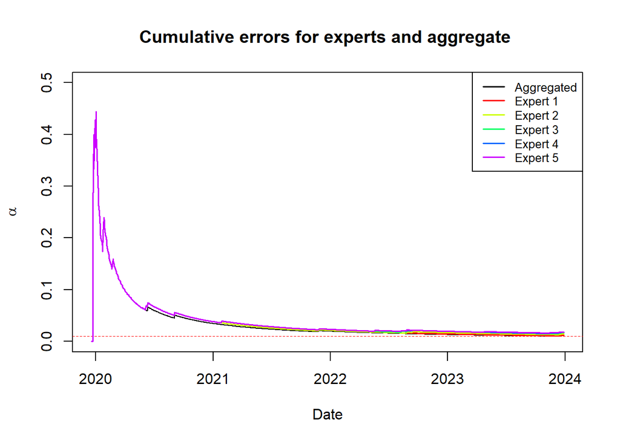

```r
par(mfrow = c(1, 1))

# Distinct colors for each expert
colors <- rainbow(K)

# Create an empty plot for all errors
plot(date[-1], cummean(err[-1]), type = "l", col = "black",
     ylim = c(0, 0.5),
     main = "Cumulative errors for experts and aggregate ",
     xlab = "Date", ylab = expression(alpha))

# Add a horizontal line for the threshold
abline(h = 0.01, col = "red", lwd = 0.3, lty = 2)

# Add lines for each expert with distinct colors
for (k in 1:K) {
    lines(date[-1], cummean(errSeqOC[k,-1]), col = colors[k], lwd = 1.5)
}

# Add a legend to distinguish experts
legend("topright", legend = c("Aggregated", paste("Expert", 1:K)),
       col = c("black", colors), lty = 1, lwd = 1.5, cex = 0.8)
```

## Comments on results:

### The Naive Strategy

The **naive strategy** is an adaptive method designed to dynamically select the value of $\gamma$ based on the observed efficiency and validity of predictive intervals constructed in previous steps. The strategy is applied after an initial “warm-up” period and involves calculating the optimal $\gamma$ from a user-defined grid of values. Below is a detailed explanation:

The selection of the optimal $\gamma$ is based on past performance, particularly after a **warm-up period**. During the first $T_w$ steps, the strategy operates arbitrarily, using a predefined value (e.g., $\gamma = 0$) instead of selecting the optimal $\gamma$. This warm-up phase allows the system to “warm-up” and gather enough data for later choosing an appropriate value for $\gamma$. Once the warm-up period ends, i.e., for each $t \geq T_0 + T_w$, the strategy begins selecting $\gamma_{k^*}$ based on past performance, aiming to minimize the length of the predictive intervals while ensuring their validity. The selection of $\gamma_{k^*}$ is formalized as follows:

$$k^*_{t+1} \in \arg\min_{k \in A_t}
\left( t^{-1}\sum_{s=1}^{t} \text{length}(C_{\alpha_{s,k}}(x_s))
\right),$$

where
$$A_t = \left\{ k \in [1,K] \mid
t^{-1} \sum_{s=1}^{t} \mathbb{I}_{y_s \in C_{\alpha_{s,k}}(x_s)} \geq 1
- \alpha \right\}$$
represents the set of candidate values for $\gamma_k$. This condition ensures the validity of the predictive intervals by maintaining the miscoverage below a threshold $(1 - \alpha)$. If $A_t=\emptyset$ instead, we take $\gamma_{k^*}$ as:
$$k^*_{t+1} \in \arg\min_{k \in [1,K]} ( |
1-\alpha- t^{-1}\sum_{s=1}^{t} \mathbb{I}_{y_s \in
C_{\alpha_{s,k}}(x_s)} | ),$$

```r
library(quantmod)
library(PerformanceAnalytics)
```

```r
library(rugarch)
library(dplyr)
#Download the historical data of Microsoft (MSFT) from 2015 to 2023
getSymbols("MSFT", from = "2015-01-01", to = "2023-12-31")
```

```
## [1] "MSFT"
```

```r
msft <- Cl(MSFT)     # Estrai i prezzi di chiusura

# Daily returns calculation
returns <- dailyReturn(msft)
returns <- na.omit(returns)  # Rimuovo eventuali valori NA


garchNaiveStrategy <- function(returns, alpha = 0.05,
                               gammaGrid = seq(0.001, 0.01, by = 0.001),
                               lookback = 1250, garchP = 1, garchQ = 1,
                               startUp = 100, warmUp = 50,
                               garchType = "sGARCH", verbose = FALSE) {

  myT <- length(returns)
  T0  <- max(startUp, lookback)

  # Prepare the matrices and support vectors
  nGamma <- length(gammaGrid)
  nSteps <- myT - T0 + 1

  scores     <- matrix(0,  nrow = nSteps, ncol = nGamma)
  errSeq     <- matrix(0,  nrow = nSteps, ncol = nGamma)
  alphaSeq   <- matrix(alpha, nrow = nSteps, ncol = nGamma)

  # Interval length for each gamma at each step: (nSteps x nGamma)
  intervalLengths <- matrix(Inf, nrow = nSteps, ncol = nGamma)

  # For the selected gamma
  selectedErrSeq           <- rep(0, nSteps)
  selectedIntervalLengths  <- rep(0, nSteps)
  selectedAlphaSeq         <- rep(0, nSteps)
  bestGammaIndex           <- rep(1, nSteps)

  # GARCH model specification
  garchSpec <- ugarchspec(
    mean.model = list(armaOrder = c(0, 0), include.mean = FALSE),
    variance.model = list(model = garchType, garchOrder = c(garchP, garchQ)),
    distribution.model = "std"
  )

  # ===============================================================
  # Loop principale
  # ===============================================================
  for (t in T0:myT) {


    #GARCH model fitting
    garchFit  <- ugarchfit(garchSpec, returns[(t - lookback + 1):(t - 1)], solver = "hybrid")
    sigmaNext <- sigma(ugarchforecast(garchFit, n.ahead = 1))

    # Conformity score calculation
    # (e.g., relative difference between realized variance and forecast variance)
    for (k in seq_along(gammaGrid)) {
      gamma <- gammaGrid[k]

      # step index
      stepIdx <- t - T0 + 1

      scores[stepIdx, k] <- abs(returns[t]^2 - sigmaNext^2) / sigmaNext^2

      # Subsample of recent scores for quantile calculation
      recentScores <- scores[max(stepIdx - lookback + 1, 1):stepIdx, k]

      # Threshold estimation
      if (t == T0) {
        # Use the 'fixed' alpha value in the first step
        qValue <- quantile(recentScores, 1 - alpha, na.rm = TRUE)
      } else {
        # In the next step, we use the updated alphaSeq
        qValue <- quantile(recentScores, 1 - alphaSeq[stepIdx - 1, k], na.rm = TRUE)
      }

      # Calculation of error and interval length.
      errSeq[stepIdx, k] <- as.numeric(scores[stepIdx, k] > qValue)
      intervalLengths[stepIdx, k] <- 2 * qValue  # intervallo +/- qValue

      # Update alphaSeq for the next step.
      if (stepIdx >= 2) {
        alphaSeq[stepIdx, k] <- alphaSeq[stepIdx - 1, k] + gamma * (alpha - errSeq[stepIdx, k])
        # Clipping to avoid values less than 0 or greater than 1.
        alphaSeq[stepIdx, k] <- min(1, max(0, alphaSeq[stepIdx, k]))
      }
    }

    # ---------------------------------------------------------------
    # Selection of the optimal gamma
    # ---------------------------------------------------------------
    stepIdx <- t - T0 + 1

    if (t < T0 + warmUp) {
      # During the warm-up: we always use gammaGrid[1], for example.
      gammaIdx <- 1
    } else {
      # After the warm-up, we select the gammas that have had average errors <= alpha so far
      # Among these, we select the one with the minimum average length
      validGammas <- which(colMeans(errSeq[1:stepIdx, , drop = FALSE]) <= alpha)

      if (length(validGammas) > 0) {
        # Among the valid gammas, I take the one with the smallest average interval
        mediaLunghezze <- colMeans(intervalLengths[1:stepIdx, validGammas, drop = FALSE])
        bestIndex      <- which.min(mediaLunghezze)
        gammaIdx       <- validGammas[bestIndex]
      } else {
        # "If there is no gamma with an average error <= alpha, I take the gamma with the average error closest to alpha
        mediaErrori    <- colMeans(errSeq[1:stepIdx, , drop = FALSE])
        gammaIdx       <- which.min(abs(mediaErrori - alpha))
      }
    }

    bestGammaIndex[stepIdx] <- gammaIdx

    # Construction of the interval with the selected gamma
    selectedRecentScores <- scores[max(stepIdx - lookback + 1, 1):stepIdx, gammaIdx]

    if (t == T0) {
      # First step
      qValue <- quantile(selectedRecentScores, 1 - alpha, na.rm = TRUE)
      selectedAlphaSeq[stepIdx] <- alpha
    } else {
      qValue <- quantile(selectedRecentScores, 1 - alphaSeq[stepIdx - 1, gammaIdx], na.rm = TRUE)
      selectedAlphaSeq[stepIdx] <- alphaSeq[stepIdx - 1, gammaIdx]
    }

    selectedErrSeq[stepIdx]          <- as.numeric(scores[stepIdx, gammaIdx] > qValue)
    selectedIntervalLengths[stepIdx] <- 2 * qValue
  }

  # ===============================================================
  # Calculation of the average interval lengths
  # ===============================================================
  # 1) Average for each gamma (vector of length = nGamma)
  avgIntervalLenPerGamma <- colMeans(intervalLengths, na.rm = TRUE)

  # 2) Average interval for the selected gamma
  avgIntervalLenSelected <- mean(selectedIntervalLengths, na.rm = TRUE)


  # ===============================================================
  # Calculation of the medians of interval lengths
  # ===============================================================
  # 1) Median for each gamma
  medianIntervalLenPerGamma <- apply(intervalLengths, 2, median, na.rm = TRUE)

  # 2) Median of the interval for the selected gamma
  medianIntervalLenSelected <- median(selectedIntervalLengths, na.rm = TRUE)

  # If we want to print (if verbose = TRUE):
  if (verbose) {
    cat("\n===============================================\n")
    cat("Average interval length for EACH gamma:\n")
    print(avgIntervalLenPerGamma)

    cat("\nAverage interval length for the SELECTED gamma:\n")
    print(avgIntervalLenSelected)

    cat("\n---\n\nMedian interval length for EACH gamma:\n")
    print(medianIntervalLenPerGamma)

    cat("\nMedian interval length for the SELECTED gamma:\n")
    print(medianIntervalLenSelected)
    cat("===============================================\n")
  }

  # ===============================================================
  # Final result
  # ===============================================================
  return(list(
    alphaSeq                = alphaSeq,
    errSeq                  = errSeq,
    intervalLengths         = intervalLengths,
    bestGammaIndex          = bestGammaIndex,
    selectedErrSeq          = selectedErrSeq,
    selectedIntervalLengths = selectedIntervalLengths,
    selectedAlphaSeq        = selectedAlphaSeq,

    # Medie su queste lunghezze
    avgIntervalLenPerGamma  = avgIntervalLenPerGamma,
    avgIntervalLenSelected  = avgIntervalLenSelected,

    # Medianas of these lengths
    medianIntervalLenPerGamma  = medianIntervalLenPerGamma,
    medianIntervalLenSelected  = medianIntervalLenSelected
  ))
}


results <- garchNaiveStrategy(
  returns   = returns,
  alpha     = 0.05,
  gammaGrid = seq(0.001, 0.010, by = 0.001),
  lookback  = 1250,
  garchP    = 1,
  garchQ    = 1,
  startUp   = 100,
  warmUp    = 50,
  verbose   = TRUE
)
```

```
##
## ===============================================
## Average interval length for EACH gamma:
##  [1] 6.746173 6.901056 7.202726 7.239034 7.460935 7.578465 7.649217 7.606568
##  [9] 7.823446 7.872616
##
## Average interval length for the SELECTED gamma:
## [1] 7.194258
##
## ---
##
## Median interval length for EACH gamma:
##  [1] 6.873996 6.938913 6.976310 6.970595 7.006243 7.123205 6.968306 6.932987
##  [9] 6.962098 6.955754
##
## Median interval length for the SELECTED gamma:
## [1] 6.829778
## ===============================================
```

```r
# Visualization of the results
date <- index(returns)[1250:length(index(returns))]
cat("\n===============================================\n")
cat("Average interval length for EACH gamma:\n")
```

```
## Average interval length for EACH gamma:
```

```r
print(results$avgIntervalLenPerGamma)
```

```
##  [1] 6.746173 6.901056 7.202726 7.239034 7.460935 7.578465 7.649217 7.606568
##  [9] 7.823446 7.872616
```

```r
cat("\nAverage interval length for the SELECTED gamma:\n")
```

```
##
## Average interval length for the SELECTED gamma:
```

```r
print(results$avgIntervalLenSelected)
```

```
## [1] 7.194258
```

```r
cat("\n---\n\nMedian interval length for EACH gamma:\n")
```

```
##
## ---
##
## Median interval length for EACH gamma:
```

```r
print(results$medianIntervalLenPerGamma)
```

```
##  [1] 6.873996 6.938913 6.976310 6.970595 7.006243 7.123205 6.968306 6.932987
##  [9] 6.962098 6.955754
```

```r
cat("\nMedian interval length for the SELECTED gamma:\n")
```

```
##
## Median interval length for the SELECTED gamma:
```

```r
print(results$medianIntervalLenSelected)
```

```
## [1] 6.829778
```

```r
cat("===============================================\n")
```

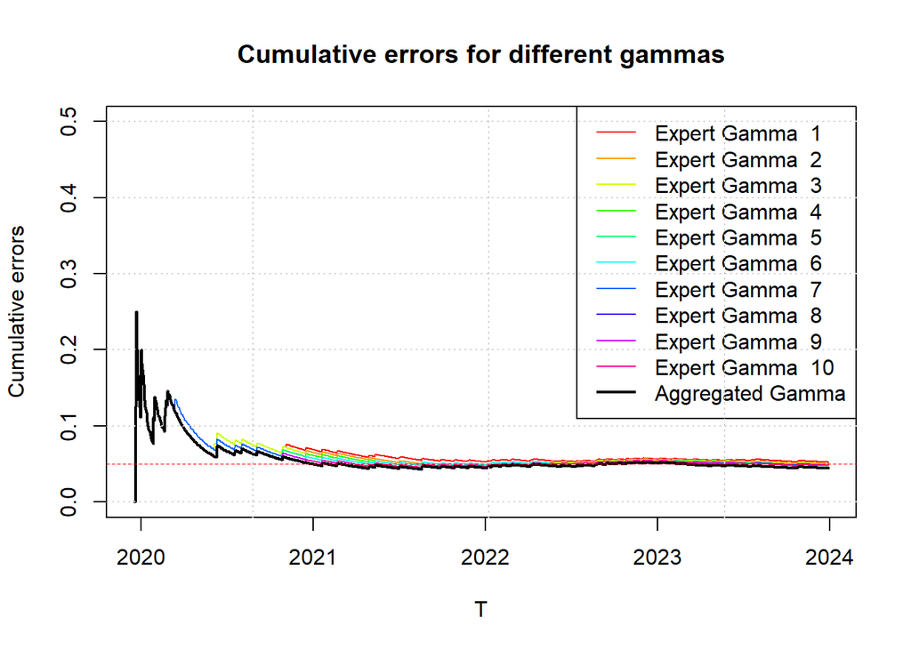

```r
# Cumulative errors (per gamma)
cumErrSeq <- apply(results$errSeq, 2, cummean)

# Colors creation for different gamma
colors <- rainbow(ncol(cumErrSeq))

# Main graph
plot(date, cumErrSeq[, 1], type = "l", col = colors[1], ylim = c(0, 0.5),
     main = "Cumulative errors for different gammas", xlab = "T", ylab = "Cumulative errors")
for (k in 2:ncol(cumErrSeq)) {
  lines(date, cumErrSeq[, k], col = colors[k])
}

# Addition of the cumulative error curve for the aggregated gamma
lines(date, cumsum(results$selectedErrSeq) / seq_along(results$selectedErrSeq),
      col = "black", lwd = 2)

abline(h = 0.05, col = "red", lwd = 0.3, lty = 2)

# Legend creation
legend("topright",
       legend = c(paste0("Expert Gamma  ", 1:ncol(cumErrSeq)), "Aggregated Gamma"),
       col = c(colors, "black"),
       lwd = c(rep(1, ncol(cumErrSeq)), 2))
grid()
```